# Practical Machine Learning: Course project writeup

Leandro Jimenez

Saturday, December 26, 2015

### Background and Introduction

Using devices such as Jawbone Up, Nike FuelBand, and Fitbit it is now possible to collect a large amount of data about personal activity relatively inexpensively. These type of devices are part of the quantified self movement - a group of enthusiasts who take measurements about themselves regularly to improve their health, to find patterns in their behavior, or because they are tech geeks.

One thing that people regularly do is quantify how much of a particular activity they do, but they rarely quantify how well they do it. In this project, we will use data recorded from accelerometers on the belt, forearm, arm, and dumbbell of 6 participants. They were asked to perform barbell lifts correctly and incorrectly in 5 different ways.

More information is available from the website [http://groupware.les.inf.puc-rio.br/har] [1] (see the section on the Weight Lifting Exercise Dataset). [1]: http://groupware.les.inf.puc-rio.br/har

This document is the write-up submission for the course Practical Machine Learning by Jeff Leek, PhD, Professor at Johns Hopkins University, Bloomberg School of Public Health. This 4-week course was offered on Coursera in June 2015, and is part of Johns Hopkins Data Science Specialization.

### Data Description

The training data for this project are available here: [https://d396qusza40orc.cloudfront.net/predmachlearn/pml-training.csv] [2]

[2]: [https://d396qusza40orc.cloudfront.net/predmachlearn/pml-training.csv]

The test data are available here: https://d396qusza40orc.cloudfront.net/predmachlearn/pml-testing.csv

We first download the data from the links referenced above to our computer and upload the files into R (using RStudio), interpreting the miscellaneous NA, #DIV/0! and empty fields as NA:

save the Urls and read data. Then, visually reviewed the data to cleanup NA, DIV/0!, blank data on import and store locally

```r
library(caret)
library(rpart)
library(randomForest)
library(rattle)
```

```r
library(rpart)
library(rpart.plot)
```

```r
trainSource <- "http://d396qusza40orc.cloudfront.net/predmachlearn/pml-training.csv"
testSource <- "http://d396qusza40orc.cloudfront.net/predmachlearn/pml-testing.csv"

download.file(trainSource, destfile = "pml-testing.csv")
download.file(testSource, destfile = "pml-training.csv")


trainData <- read.csv(url(trainSource), na.strings=c("NA","#DIV/0!",""))
testData <- read.csv(url(testSource), na.strings=c("NA","#DIV/0!",""))
```

Dimensions

```r
dim(trainData)
```

```
## [1] 19622   160
```

```r
dim(testData)
```

```
## [1]  20 160
```

### Processing of data

#### get columns of Interest as predictors

Pollect data on all columns that have all NA values in the testData dataset. Remove the those ‘NA’ columns from both datasets

```r
id_NA_Cols <- sapply(testData,function(x)any(is.na(x)))
trainData <- trainData[,!(id_NA_Cols)]
testData <- testData[,!(id_NA_Cols)]
```

```r
trainData <- trainData[, -1]
testData <- testData[, -1]
testData <- testData[, -length(colnames(testData))]
```

New dimensions

```r
dim(trainData)
```

```
## [1] 19622    59
```

```r
dim(testData)
```

```
## [1] 20 58
```

The trainData was partitioned into training (workingTraining) and testing (workingTesting) subsets.

```r
inTrain <- createDataPartition(y=trainData$classe, p=0.6, list=FALSE)
workingTraining <- trainData[inTrain,]
workingTesting <- trainData[-inTrain,]
dim(workingTraining)
```

```
## [1] 11776    59
```

```r
dim(workingTesting)
```

```
## [1] 7846   59
```

### Decision Tree

```r
modelrpart2 <- rpart(classe ~ ., data=workingTraining, method="class")
```

Plot tree

[figure not shown]

```r
#plot(modelrpart2)
#text(modelrpart2, use.n=FALSE, all=FALSE, cex=.5)
fancyRpartPlot(modelrpart2) #prettiest
```

Prediction and Confusion Matrix

```r
#predict
predictrpart2 <- predict(modelrpart2, workingTesting, type="class")

#confusion matrix
confusionMatrix(predictrpart2, workingTesting$classe)
```

```
## Confusion Matrix and Statistics
##
##           Reference
## Prediction    A    B    C    D    E
##          A 2153   65    7    0    0
##          B   63 1307  156   64    0
##          C   16  138 1186  153   60
##          D    0    8   19 1014  183
##          E    0    0    0   55 1199
##
## Overall Statistics
##
##                Accuracy : 0.8742
##                  95% CI : (0.8667, 0.8815)
##     No Information Rate : 0.2845
##     P-Value [Acc > NIR] : < 2.2e-16
##
##                   Kappa : 0.8409
##  Mcnemar's Test P-Value : NA
##
## Statistics by Class:
##
##                      Class: A Class: B Class: C Class: D Class: E
## Sensitivity            0.9646   0.8610   0.8670   0.7885   0.8315
## Specificity            0.9872   0.9553   0.9433   0.9680   0.9914
## Pos Pred Value         0.9676   0.8220   0.7637   0.8284   0.9561
## Neg Pred Value         0.9859   0.9663   0.9711   0.9589   0.9631
## Prevalence             0.2845   0.1935   0.1744   0.1639   0.1838
## Detection Rate         0.2744   0.1666   0.1512   0.1292   0.1528
## Detection Prevalence   0.2836   0.2027   0.1979   0.1560   0.1598
## Balanced Accuracy      0.9759   0.9081   0.9052   0.8782   0.9114
```

### Random Forests

```r
#library(randomForest)
modelrf2 <- randomForest(classe ~ ., data=workingTraining)
print(modelrf2)
```

```
##
## Call:
##  randomForest(formula = classe ~ ., data = workingTraining)
##                Type of random forest: classification
##                      Number of trees: 500
## No. of variables tried at each split: 7
##
##         OOB estimate of  error rate: 0.17%
## Confusion matrix:
##      A    B    C    D    E  class.error
## A 3347    1    0    0    0 0.0002986858
## B    1 2278    0    0    0 0.0004387889
## C    0    4 2047    3    0 0.0034079844
## D    0    0    8 1921    1 0.0046632124
## E    0    0    0    2 2163 0.0009237875
```

Importance was examined and plotted.

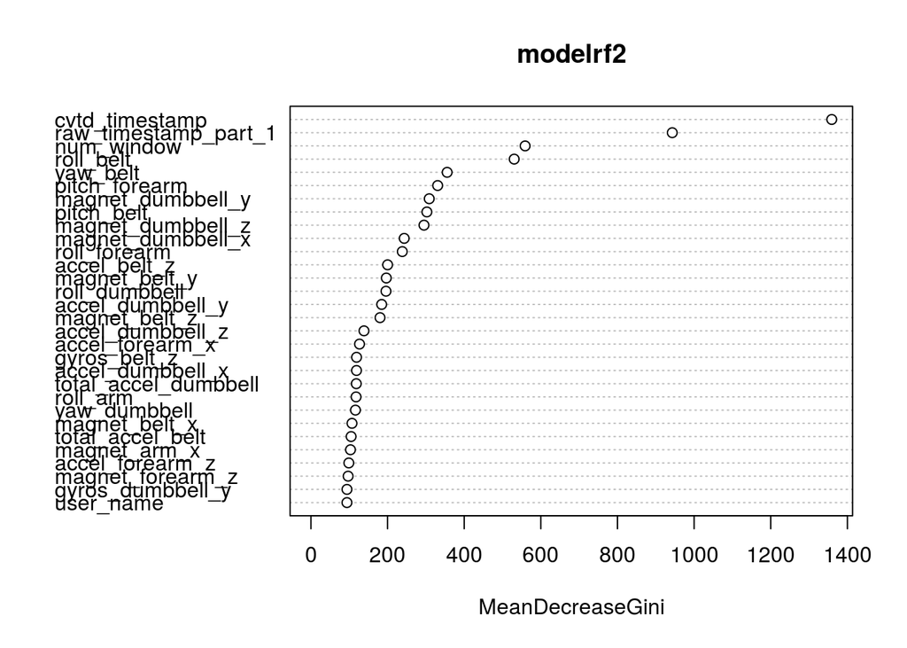

```r
#importance(modelrf2)
varImpPlot(modelrf2) #cool
```

### Prediction and Confusion Matrix

```r
#predict
predictrf2 <- predict(modelrf2, workingTesting, type="class")

#confusion matrix
confusionMatrix(predictrf2, workingTesting$classe)
```

```
## Confusion Matrix and Statistics
##
##           Reference
## Prediction    A    B    C    D    E
##          A 2232    6    0    0    0
##          B    0 1512    3    0    0
##          C    0    0 1362    6    0
##          D    0    0    3 1280    0
##          E    0    0    0    0 1442
##
## Overall Statistics
##
##                Accuracy : 0.9977
##                  95% CI : (0.9964, 0.9986)
##     No Information Rate : 0.2845
##     P-Value [Acc > NIR] : < 2.2e-16
##
##                   Kappa : 0.9971
##  Mcnemar's Test P-Value : NA
##
## Statistics by Class:
##
##                      Class: A Class: B Class: C Class: D Class: E
## Sensitivity            1.0000   0.9960   0.9956   0.9953   1.0000
## Specificity            0.9989   0.9995   0.9991   0.9995   1.0000
## Pos Pred Value         0.9973   0.9980   0.9956   0.9977   1.0000
## Neg Pred Value         1.0000   0.9991   0.9991   0.9991   1.0000
## Prevalence             0.2845   0.1935   0.1744   0.1639   0.1838
## Detection Rate         0.2845   0.1927   0.1736   0.1631   0.1838
## Detection Prevalence   0.2852   0.1931   0.1744   0.1635   0.1838
## Balanced Accuracy      0.9995   0.9978   0.9973   0.9974   1.0000
```

### Apply The Models

```r
finalPredictionrpart <- predict(modelrpart2, testData, type="class")
finalPredictionrpart
```

```
##  1  2  3  4  5  6  7  8  9 10 11 12 13 14 15 16 17 18 19 20
##  B  A  C  A  A  E  D  C  A  A  B  C  B  A  E  E  A  B  B  B
## Levels: A B C D E
```